# Flights Dataset

## Introduction

This dataset reports flights in the United States, including carriers, arrival and departure delays and reasons for delays for the year 1987.

```python
# import all packages and set plots to be embedded inline
import numpy as np
import pandas as pd
import matplotlib.pyplot as plt
import seaborn as sb

%matplotlib inline
```

```python
# read the data frame
df = pd.read_csv('1987.csv')
df.head()
```

|  | Year | Month | DayofMonth | DayOfWeek | DepTime | CRSDepTime | ArrTime | CRSArrTime | UniqueCarrier | FlightNum | ... | TaxiIn | TaxiOut | Cancelled | CancellationCode | Diverted | CarrierDelay | WeatherDelay | NASDelay | SecurityDelay | LateAircraftDelay |
| --- | --- | --- | --- | --- | --- | --- | --- | --- | --- | --- | --- | --- | --- | --- | --- | --- | --- | --- | --- | --- | --- |
| 0 | 1987 | 10 | 14 | 3 | 741.0 | 730 | 912.0 | 849 | PS | 1451 | ... | NaN | NaN | 0 | NaN | 0 | NaN | NaN | NaN | NaN | NaN |
| 1 | 1987 | 10 | 15 | 4 | 729.0 | 730 | 903.0 | 849 | PS | 1451 | ... | NaN | NaN | 0 | NaN | 0 | NaN | NaN | NaN | NaN | NaN |
| 2 | 1987 | 10 | 17 | 6 | 741.0 | 730 | 918.0 | 849 | PS | 1451 | ... | NaN | NaN | 0 | NaN | 0 | NaN | NaN | NaN | NaN | NaN |
| 3 | 1987 | 10 | 18 | 7 | 729.0 | 730 | 847.0 | 849 | PS | 1451 | ... | NaN | NaN | 0 | NaN | 0 | NaN | NaN | NaN | NaN | NaN |
| 4 | 1987 | 10 | 19 | 1 | 749.0 | 730 | 922.0 | 849 | PS | 1451 | ... | NaN | NaN | 0 | NaN | 0 | NaN | NaN | NaN | NaN | NaN |

5 rows × 29 columns

```python
df.shape
```

```
(1311826, 29)
```

```python
df.describe()
```

|  | Year | Month | DayofMonth | DayOfWeek | DepTime | CRSDepTime | ArrTime | CRSArrTime | FlightNum | TailNum | ... | TaxiIn | TaxiOut | Cancelled | CancellationCode | Diverted | CarrierDelay | WeatherDelay | NASDelay | SecurityDelay | LateAircraftDelay |
| --- | --- | --- | --- | --- | --- | --- | --- | --- | --- | --- | --- | --- | --- | --- | --- | --- | --- | --- | --- | --- | --- |
| count | 1311826.0 | 1.311826e+06 | 1.311826e+06 | 1.311826e+06 | 1.292141e+06 | 1.311826e+06 | 1.288326e+06 | 1.311826e+06 | 1.311826e+06 | 0.0 | ... | 0.0 | 0.0 | 1.311826e+06 | 0.0 | 1.311826e+06 | 0.0 | 0.0 | 0.0 | 0.0 | 0.0 |
| mean | 1987.0 | 1.099374e+01 | 1.571761e+01 | 3.949043e+00 | 1.369276e+03 | 1.361131e+03 | 1.493152e+03 | 1.491052e+03 | 6.701427e+02 | NaN | ... | NaN | NaN | 1.500580e-02 | NaN | 2.908160e-03 | NaN | NaN | NaN | NaN | NaN |
| std | 0.0 | 8.232012e-01 | 8.835640e+00 | 1.986290e+00 | 4.787183e+02 | 4.719701e+02 | 4.987503e+02 | 4.868002e+02 | 5.145510e+02 | NaN | ... | NaN | NaN | 1.215756e-01 | NaN | 5.384891e-02 | NaN | NaN | NaN | NaN | NaN |
| min | 1987.0 | 1.000000e+01 | 1.000000e+00 | 1.000000e+00 | 1.000000e+00 | 1.000000e+00 | 1.000000e+00 | 1.000000e+00 | 1.000000e+00 | NaN | ... | NaN | NaN | 0.000000e+00 | NaN | 0.000000e+00 | NaN | NaN | NaN | NaN | NaN |
| 25% | 1987.0 | 1.000000e+01 | 8.000000e+00 | 2.000000e+00 | 9.460000e+02 | 9.400000e+02 | 1.117000e+03 | 1.115000e+03 | 2.910000e+02 | NaN | ... | NaN | NaN | 0.000000e+00 | NaN | 0.000000e+00 | NaN | NaN | NaN | NaN | NaN |
| 50% | 1987.0 | 1.100000e+01 | 1.600000e+01 | 4.000000e+00 | 1.345000e+03 | 1.338000e+03 | 1.521000e+03 | 1.519000e+03 | 5.600000e+02 | NaN | ... | NaN | NaN | 0.000000e+00 | NaN | 0.000000e+00 | NaN | NaN | NaN | NaN | NaN |
| 75% | 1987.0 | 1.200000e+01 | 2.300000e+01 | 6.000000e+00 | 1.750000e+03 | 1.742000e+03 | 1.918000e+03 | 1.912000e+03 | 8.940000e+02 | NaN | ... | NaN | NaN | 0.000000e+00 | NaN | 0.000000e+00 | NaN | NaN | NaN | NaN | NaN |
| max | 1987.0 | 1.200000e+01 | 3.100000e+01 | 7.000000e+00 | 2.400000e+03 | 2.359000e+03 | 2.400000e+03 | 2.400000e+03 | 6.282000e+03 | NaN | ... | NaN | NaN | 1.000000e+00 | NaN | 1.000000e+00 | NaN | NaN | NaN | NaN | NaN |

8 rows × 26 columns

```python
df['Distance'].mean()
```

```
591.2441015523978
```

```python
# Fill the null values in the columns
df['ArrDelay'].fillna(9.44,inplace=True)
df['Distance'].fillna(591.24,inplace=True)
```

```python
df.info()
```

[output not shown]

### What is the structure of your dataset?

The dataset has 29 columns and 1311826 rows

### What is/are the main feature(s) of interest in your dataset?

> Your answer here! I am intrested to find out the features involved in the arrivals delay of the flight.

### What features in the dataset do you think will help support your investigation into your feature(s) of interest?

> Your answer here!The distance and departure delay and diverted features would support me in investigating the ArrDelay

## Univariate Exploration

> In this section, investigate distributions of individual variables. If you see unusual points or outliers, take a deeper look to clean things up and prepare yourself to look at relationships between variables.

I will plot each individual variable which are the main feature of interest and support in finding the main feature of interest

```python
df.ArrDelay
```

```
0           23.0
1           14.0
2           29.0
3           -2.0
4           33.0
5           -1.0
6            3.0
7           13.0
8           19.0
9            2.0
10          15.0
11          24.0
12          11.0
13          -7.0
14          34.0
```

[output cut: 47 more lines]

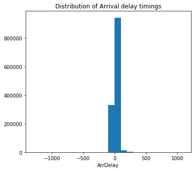

```python
# Let us begin with histograms to plot individual variables
plt.figure(figsize = [8, 6])

bin_edge= np.arange(df['ArrDelay'].min(),df['ArrDelay'].max()+100,100)
plt.figure(figsize=[ 6, 5.27])
plt.hist(data = df,x='ArrDelay',bins = bin_edge);
plt.xlabel('ArrDelay')
plt.title('Distribution of Arrival delay timings');
```

I will try with a smaller bin to see the how spread ot the range of values are

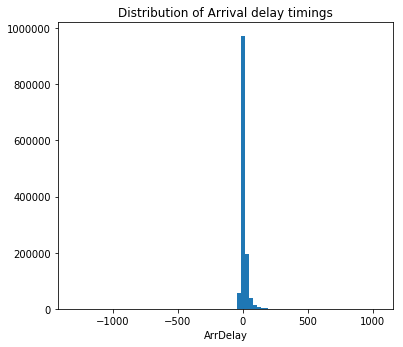

```python
# plotting a histogram with a smaller bin
plt.figure(figsize = [8, 6])
bin_edge= np.arange(df['ArrDelay'].min(),df['ArrDelay'].max()+30,30)
plt.figure(figsize=[ 6, 5.27])
plt.hist(data = df,x='ArrDelay',bins = bin_edge);
plt.xlabel('ArrDelay')
plt.title('Distribution of Arrival delay timings');
```

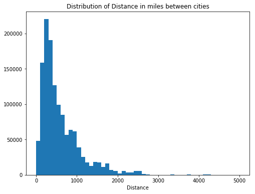

```python
# Plot the histogram of Distance variable
plt.figure(figsize = [8, 6])
bin = np.arange(df['Distance'].min(),df['Distance'].max()+100,100)
plt.hist(data =df,x='Distance',bins= bin )
plt.xlabel('Distance')
plt.title('Distribution of Distance in miles between cities');
```

The plot appears to be skewed to the right, so i need to do the transformation.

```python
# I have done the transformation to convert it into a normalised distribution.
np.log10(df['Distance']).describe()
```

[output not shown]

```
count    1.310811e+06
mean             -inf
std               NaN
min              -inf
25%      2.392697e+00
50%      2.619093e+00
75%      2.895975e+00
max      3.697491e+00
Name: Distance, dtype: float64
```

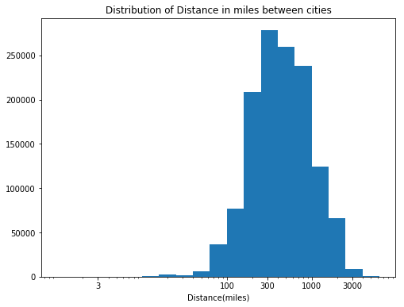

```python
# plot after applying the transformation
plt.figure(figsize = [8, 6])
bins = 10 ** np.arange(0,3.69+0.2,0.2)
ticks = [3,100,300,1000,3000]
labels = ['{}'.format(v) for v in ticks]
plt.hist(data = df,x='Distance',bins = bins)
plt.xscale('log')
plt.xticks(ticks,labels)
plt.xlabel('Distance(miles)')
plt.title('Distribution of Distance in miles between cities');
```

[figure not shown]

```python
# plot using DepDelay variable
plt.figure(figsize = [8, 6])
bin_edges = np.arange(df['DepDelay'].min(),df['DepDelay'].max()+100,100)
plt.hist(data=df,x= 'DepDelay',bins = bin_edges)
plt.xlabel('DepDelay')
plt.title('Histogram')
plt.title('Distribution of Distance in miles between cities');
```

I will try with a smaller bin size

[figure not shown]

```python
# plot DepDelay variable with smaller bin size
plt.figure(figsize = [8, 6])
bin_edges = np.arange(df['DepDelay'].min(),df['DepDelay'].max()+50,50)
plt.hist(data=df,x= 'DepDelay',bins = bin_edges)
plt.xlabel('DepDelay')
plt.title('Distribution of Distance in miles between cities');
```

### Of the features you investigated, were there any unusual distributions? Did you perform any operations on the data to tidy, adjust, or change the form of the data? If so, why did you do this?

> Your answer here! The Distance variable was skewed to the right so i had to apply a log transformation to convert it to a normal distribution and reduce the bin size to make the distributions look more spread

## Bivariate Exploration

> In this section, investigate relationships between pairs of variables in your data. Make sure the variables that you cover here have been introduced in some fashion in the previous section (univariate exploration).

Let us begin by plotting a scatterplot for showing relationship between 2 quantitative variables i.e the variable of interest ArrDelay with the supporting variable Distance

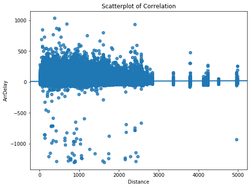

```python
# plot a regplot to show the relationship between 2 variables Distance and ArrDelay
plt.figure(figsize = [8, 6])
sb.regplot(data=df, x='Distance',y='ArrDelay')
plt.xlabel('Distance')
plt.ylabel('ArrDelay')
plt.title('Scatterplot of Correlation');
```

The line does not show any positive or negative trend, next i will plot a line plot to further investigate relationship between both the variables

```python
# plot a line plot to show the relationship
bins = np.arange(df['Distance'].min(),df['Distance'].max()+100,100)
nins_e= bins[:-1] + 500
dis_binned = pd.cut(df['Distance'],bins,include_lowest= True)
Arr_mean=df['ArrDelay'].groupby(dis_binned).mean()
Arr_std= df['ArrDelay'].groupby(dis_binned).std()
```

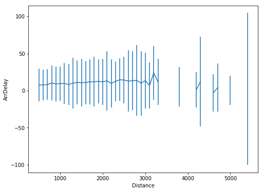

```python
plt.figure(figsize = [8, 6])
plt.errorbar(x=nins_e,y=Arr_mean,yerr= Arr_std)
plt.xlabel('Distance')
plt.ylabel('ArrDelay')
plt.title('Correlation of Arrival delay and distance')
```

The line plot gives the same results as the scatter plot , and it has some missing data in between the line

I will plot a scatterplot to see the relationshionship between Arrival and departure

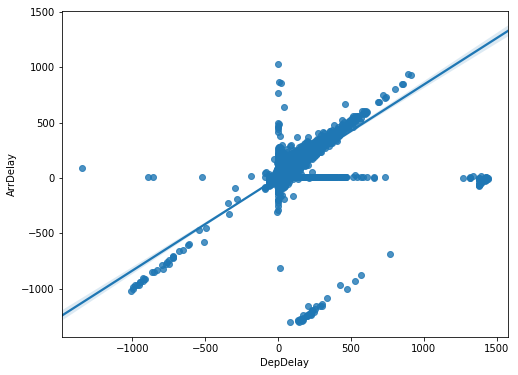

```python
# show the relationship between ArrDelay and DepDelay
plt.figure(figsize = [8, 6])
sb.regplot(data=df,x='DepDelay',y='ArrDelay')
plt.xlabel('DepDelay')
plt.ylabel('ArrDelay')
plt.title('Correlation of Arrival delay and departure delay');
```

The plot clearly shows an upward positive trend where the increase in departure delay lead to increase in arrival delay means these variables are positively correlated

```python
# plot a line plot for further investigation
bins = np.arange(df['DepDelay'].min(),df['ArrDelay'].max()+50,50)
bins_c= bins[:-1] + 10
dis_binned = pd.cut(df['Distance'],bins,include_lowest= True)
Arr_mean=df['ArrDelay'].groupby(dis_binned).mean()
```

[figure not shown]

```python
plt.figure(figsize = [8, 6])
plt.errorbar(x=bins_c,y=Arr_mean)
plt.xlabel('DepDelay')
plt.ylabel('ArrDelay')
plt.title('Lineplot of Correlation');
```

The next plot will be relationship between departure delay and Distance. These are 2 supporting variables

[output not shown]

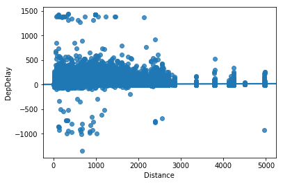

```python
# Investigate the relationship between DepDelay and Distance using regplot
sb.regplot(data=df,x='Distance',y='DepDelay')
plt.xlabel('Distance')
plt.ylabel('DepDelay')
plt.title('Scatterplot of Correlation');
```

The line shows no upper or lower trend which shows there is no relationship between the variables. The departure does not get delayed due to large distance between the cities

I am using line plot method to try different methods of investigation

```python
# set appropriate bins for the plot
bins = np.arange(df['Distance'].min(),df['Distance'].max()+100,100)
bin_c= bins[:-1]+10
dis_binned = pd.cut(df['Distance'],bins,include_lowest= True)
Arr_mean=df['DepDelay'].groupby(dis_binned).mean()
Arr_std=df['DepDelay'].groupby(dis_binned).std()
```

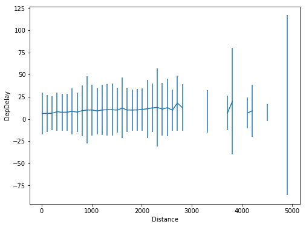

```python
# plot the figure
plt.figure(figsize = [8, 6])
plt.errorbar(x= bin_c,y=Arr_mean,yerr=Arr_std)
plt.xlabel('Distance')
plt.ylabel('DepDelay')
plt.title('Scatterplot of Correlation');
```

### Talk about some of the relationships you observed in this part of the investigation. How did the feature(s) of interest vary with other features in the dataset?

> Your answer here! The first plot doesn't show a positive or negative trend which means there is not correlation between the variables. The relationship between ArrDelay and DepDelay shows a positive trend which means there is a correlation.

### Did you observe any interesting relationships between the other features (not the main feature(s) of interest)?

> Your answer here! There are very less variables to compare and no categorial variables

## Multivariate Exploration

> Create plots of three or more variables to investigate your data even further. Make sure that your investigations are justified, and follow from your work in the previous sections.

I will begin a multivariate exploration by plotting a scatterplot with positional encodings of size and variables of DepDelay,Distance,ArrDelay

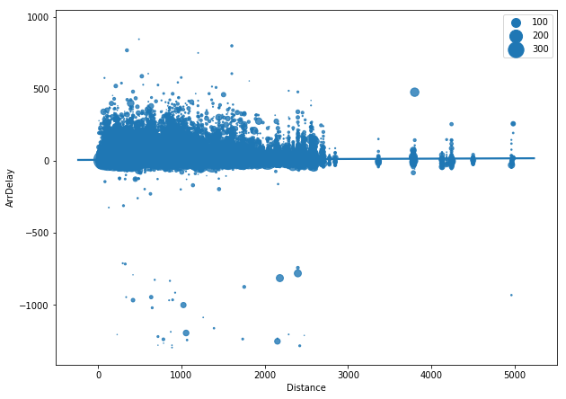

```python
# plot a scatterplot with positional encodings
plt.figure(figsize=[ 10, 7.27])
sb.regplot(data=df, x='Distance',y='ArrDelay',x_jitter=0.4,fit_reg=True
          ,scatter_kws={'s':df['DepDelay']/3})
sizes = [100,200,300]
base_color = sb.color_palette()[0]
legend_obj=[]
for s in sizes:
    legend_obj.append(plt.scatter([], [], s = s, color = base_color))
plt.legend(legend_obj, sizes)
```

Many big circles lie in the beginning of the plot at which are upwards which means DepDelay has a relationship with ArrDelay but no relationship with Distance.

To investigate the data even further i will create a Pairplot plot and this time with 4 variables by adding diverted variable

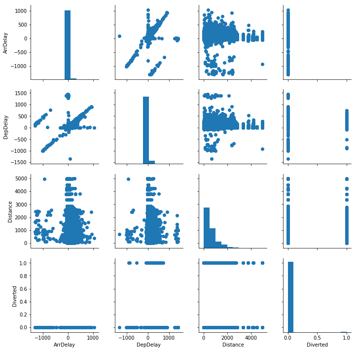

```python
# create PairGrid plots to see the relationship between 4 variables
columns= ['ArrDelay','DepDelay','Distance','Diverted']
g= sb.PairGrid(data = df, vars= columns)
g= g.map_offdiag(plt.scatter)
g.map_diag(plt.hist);
```

In this plot we can only see a relationship between departure delay and arrival delay.

I will plot using heatmaps to try different methods in multivariate exploration

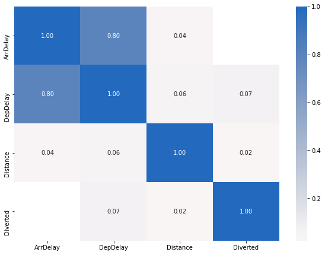

```python
# Plot using heatmaps and add colors to the boxes with 2 decimal points
plt.figure(figsize=[ 10, 7.27])
columns= ['ArrDelay','DepDelay','Distance','Diverted']
sb.heatmap(df[columns].corr(), annot = True, fmt = '.2f', cmap = 'vlag_r', center = 0)
plt.title('Heatmap of 4 variables')
```

The DepDelay and ArrDelay shows darker boxes which means there is relationship only between 2 variables. Lighter boxes shows less relationships

### Were there any interesting or surprising interactions between features?

> Your answer here! In the bivariate chart there was no relationship between the feature variables except DepDelay and ArrDelay. The same was expected after plotting the pairgrid and heatmap and scatterplots using positional encoding

```python
!jupyter nbconvert data_exploration-slide-deck.ipynb --to slides --post serve --template output-toggle.tpl --post serve
```